# Project: Investigating a Dataset of Medical Appointment No Shows

### Mainly the objective of this investigation will be to find out factor which are responsible for a patient to not show up for a Medical Appointment

- Introduction
- Data Wrangling
- Exploratory Data Analysis
- Conclusions

## Introduction

> **Dataset Used -** I downloaded No-Show appointments csv file from Kaggle and uploaded it in the root directory. Now in next cell I imported few important libraries which will be required like numpy, seaborn, matplotlib and pandas.

```python
import pandas as pd
import numpy as np
import seaborn as sns
sns.set_style('darkgrid')
import matplotlib.pyplot as plt
% matplotlib inline
```

## Data Wrangling

### Reading CSV file which is present in root directory using pandas

```python
# Load your data and print out a few lines. Perform operations to inspect data
#   types and look for instances of missing or possibly errant data.
df=pd.read_csv('no_appointment_data.csv')
df.head()
```

|  | PatientId | AppointmentID | Gender | ScheduledDay | AppointmentDay | Age | Neighbourhood | Scholarship | Hipertension | Diabetes | Alcoholism | Handcap | SMS_received | No-show |
| --- | --- | --- | --- | --- | --- | --- | --- | --- | --- | --- | --- | --- | --- | --- |
| 0 | 2.987250e+13 | 5642903 | F | 2016-04-29T18:38:08Z | 2016-04-29T00:00:00Z | 62 | JARDIM DA PENHA | 0 | 1 | 0 | 0 | 0 | 0 | No |
| 1 | 5.589978e+14 | 5642503 | M | 2016-04-29T16:08:27Z | 2016-04-29T00:00:00Z | 56 | JARDIM DA PENHA | 0 | 0 | 0 | 0 | 0 | 0 | No |
| 2 | 4.262962e+12 | 5642549 | F | 2016-04-29T16:19:04Z | 2016-04-29T00:00:00Z | 62 | MATA DA PRAIA | 0 | 0 | 0 | 0 | 0 | 0 | No |
| 3 | 8.679512e+11 | 5642828 | F | 2016-04-29T17:29:31Z | 2016-04-29T00:00:00Z | 8 | PONTAL DE CAMBURI | 0 | 0 | 0 | 0 | 0 | 0 | No |
| 4 | 8.841186e+12 | 5642494 | F | 2016-04-29T16:07:23Z | 2016-04-29T00:00:00Z | 56 | JARDIM DA PENHA | 0 | 1 | 1 | 0 | 0 | 0 | No |

### Checking rows and columns in the dataset

```python
df.shape
```

```
(110527, 14)
```

There are total 110527 rows and 14 columns

### Using various pandas function to look how the dataset looks and what types of values it hold

```python
df.info()
```

```
<class 'pandas.core.frame.DataFrame'>
RangeIndex: 110527 entries, 0 to 110526
Data columns (total 14 columns):
PatientId         110527 non-null float64
AppointmentID     110527 non-null int64
Gender            110527 non-null object
ScheduledDay      110527 non-null object
AppointmentDay    110527 non-null object
Age               110527 non-null int64
Neighbourhood     110527 non-null object
Scholarship       110527 non-null int64
Hipertension      110527 non-null int64
Diabetes          110527 non-null int64
Alcoholism        110527 non-null int64
Handcap           110527 non-null int64
SMS_received      110527 non-null int64
No-show           110527 non-null object
dtypes: float64(1), int64(8), object(5)
memory usage: 11.8+ MB
```

```python
df.dtypes
```

```
PatientId         float64
AppointmentID       int64
Gender             object
ScheduledDay       object
AppointmentDay     object
Age                 int64
Neighbourhood      object
Scholarship         int64
Hipertension        int64
Diabetes            int64
Alcoholism          int64
Handcap             int64
SMS_received        int64
No-show            object
dtype: object
```

##### As this is string I will convert into date time format to get day of week from this column

```python
type(df['ScheduledDay'][0])
```

```
str
```

```python
df.describe()
```

|  | PatientId | AppointmentID | Age | Scholarship | Hipertension | Diabetes | Alcoholism | Handcap | SMS_received |
| --- | --- | --- | --- | --- | --- | --- | --- | --- | --- |
| count | 1.105270e+05 | 1.105270e+05 | 110527.000000 | 110527.000000 | 110527.000000 | 110527.000000 | 110527.000000 | 110527.000000 | 110527.000000 |
| mean | 1.474963e+14 | 5.675305e+06 | 37.088874 | 0.098266 | 0.197246 | 0.071865 | 0.030400 | 0.022248 | 0.321026 |
| std | 2.560949e+14 | 7.129575e+04 | 23.110205 | 0.297675 | 0.397921 | 0.258265 | 0.171686 | 0.161543 | 0.466873 |
| min | 3.921784e+04 | 5.030230e+06 | -1.000000 | 0.000000 | 0.000000 | 0.000000 | 0.000000 | 0.000000 | 0.000000 |
| 25% | 4.172614e+12 | 5.640286e+06 | 18.000000 | 0.000000 | 0.000000 | 0.000000 | 0.000000 | 0.000000 | 0.000000 |
| 50% | 3.173184e+13 | 5.680573e+06 | 37.000000 | 0.000000 | 0.000000 | 0.000000 | 0.000000 | 0.000000 | 0.000000 |
| 75% | 9.439172e+13 | 5.725524e+06 | 55.000000 | 0.000000 | 0.000000 | 0.000000 | 0.000000 | 0.000000 | 1.000000 |
| max | 9.999816e+14 | 5.790484e+06 | 115.000000 | 1.000000 | 1.000000 | 1.000000 | 1.000000 | 4.000000 | 1.000000 |

##### No duplicate rows are present in the dataset.

```python
sum(df.duplicated())
```

```
0
```

```python
df['Neighbourhood'].unique()
```

```
array(['JARDIM DA PENHA', 'MATA DA PRAIA', 'PONTAL DE CAMBURI',
       'REPÚBLICA', 'GOIABEIRAS', 'ANDORINHAS', 'CONQUISTA',
       'NOVA PALESTINA', 'DA PENHA', 'TABUAZEIRO', 'BENTO FERREIRA',
       'SÃO PEDRO', 'SANTA MARTHA', 'SÃO CRISTÓVÃO', 'MARUÍPE',
       'GRANDE VITÓRIA', 'SÃO BENEDITO', 'ILHA DAS CAIEIRAS',
       'SANTO ANDRÉ', 'SOLON BORGES', 'BONFIM', 'JARDIM CAMBURI',
       'MARIA ORTIZ', 'JABOUR', 'ANTÔNIO HONÓRIO', 'RESISTÊNCIA',
       'ILHA DE SANTA MARIA', 'JUCUTUQUARA', 'MONTE BELO',
       'MÁRIO CYPRESTE', 'SANTO ANTÔNIO', 'BELA VISTA', 'PRAIA DO SUÁ',
       'SANTA HELENA', 'ITARARÉ', 'INHANGUETÁ', 'UNIVERSITÁRIO',
       'SÃO JOSÉ', 'REDENÇÃO', 'SANTA CLARA', 'CENTRO', 'PARQUE MOSCOSO',
       'DO MOSCOSO', 'SANTOS DUMONT', 'CARATOÍRA', 'ARIOVALDO FAVALESSA',
       'ILHA DO FRADE', 'GURIGICA', 'JOANA D´ARC', 'CONSOLAÇÃO',
       'PRAIA DO CANTO', 'BOA VISTA', 'MORADA DE CAMBURI', 'SANTA LUÍZA',
       'SANTA LÚCIA', 'BARRO VERMELHO', 'ESTRELINHA', 'FORTE SÃO JOÃO',
       'FONTE GRANDE', 'ENSEADA DO SUÁ', 'SANTOS REIS', 'PIEDADE',
       'JESUS DE NAZARETH', 'SANTA TEREZA', 'CRUZAMENTO',
       'ILHA DO PRÍNCIPE', 'ROMÃO', 'COMDUSA', 'SANTA CECÍLIA',
       'VILA RUBIM', 'DE LOURDES', 'DO QUADRO', 'DO CABRAL', 'HORTO',
       'SEGURANÇA DO LAR', 'ILHA DO BOI', 'FRADINHOS', 'NAZARETH',
       'AEROPORTO', 'ILHAS OCEÂNICAS DE TRINDADE', 'PARQUE INDUSTRIAL'], dtype=object)
```

```python
df['Gender'].unique()
```

```
array(['F', 'M'], dtype=object)
```

```python
df['Scholarship'].unique()
```

```
array([0, 1])
```

```python
df['Hipertension'].unique()
```

```
array([1, 0])
```

```python
df['Diabetes'].unique()
```

```
array([0, 1])
```

```python
df['Handcap'].unique()
```

```
array([0, 1, 2, 3, 4])
```

```python
df['SMS_received'].unique()
```

```
array([0, 1])
```

```python
df['No-show'].unique()
```

```
array(['No', 'Yes'], dtype=object)
```

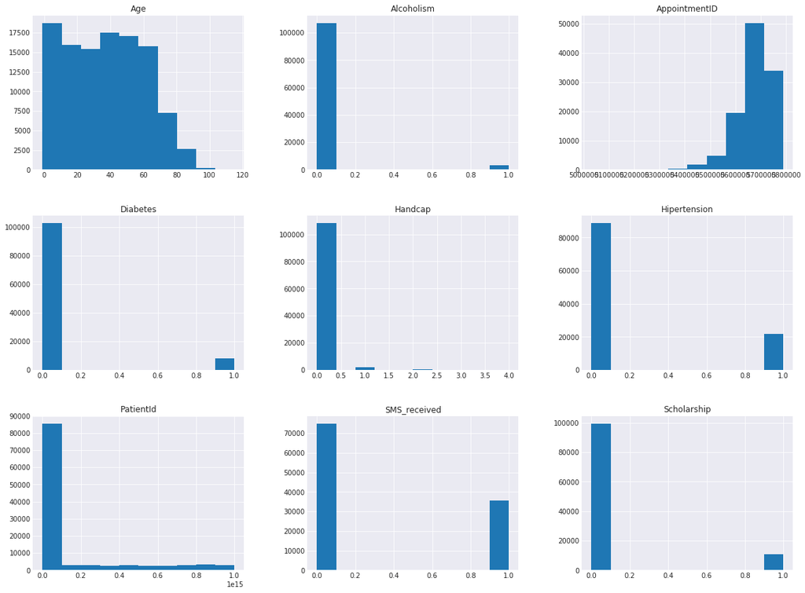

```python
#made just to get an idea of the data
df.hist(figsize=(20,15));
```

### Looking at above step I noticed few points they are as follows -

> **1**: While looking at result of df.info() it is visible that we do not have any null value in the dataset

> **2**: AppointmentDay has same value in each of its rows so we will not require PatientID, AppointmentID, AppointmentDay while investigating as they will have no link with not showing up for appointment.

> **3**: While looking at the result of df.describe() it can be seen that most of the people do not have problems like Hipertension, Diabetes, Alcoholism, Handcap

> **4**:It can be seen that in handicap column we have few rows with values >1 but in the documentation of the datset it is clearly mentioned that the values can be either true or false meaning 1 or 0 respectively. So I have decided to convert all non-zero values to true ie. 1 and all zeroes to false ie.0

### Data Cleaning (Although this dataset is already well-structured and cleaned few changes have to be made)

#### 1) Dropping three columns namely PatientID, AppointmentID, AppointmentDay as stated above at point no. 2

```python
# After discussing the structure of the data and any problems that need to be
#   cleaned, perform those cleaning steps in the second part of this section.
drop_columns=['PatientId','AppointmentID','AppointmentDay']
df.drop(columns=drop_columns,inplace=True)
df.head(5)
```

|  | Gender | ScheduledDay | Age | Neighbourhood | Scholarship | Hipertension | Diabetes | Alcoholism | Handcap | SMS_received | No-show |
| --- | --- | --- | --- | --- | --- | --- | --- | --- | --- | --- | --- |
| 0 | F | 2016-04-29T18:38:08Z | 62 | JARDIM DA PENHA | 0 | 1 | 0 | 0 | 0 | 0 | No |
| 1 | M | 2016-04-29T16:08:27Z | 56 | JARDIM DA PENHA | 0 | 0 | 0 | 0 | 0 | 0 | No |
| 2 | F | 2016-04-29T16:19:04Z | 62 | MATA DA PRAIA | 0 | 0 | 0 | 0 | 0 | 0 | No |
| 3 | F | 2016-04-29T17:29:31Z | 8 | PONTAL DE CAMBURI | 0 | 0 | 0 | 0 | 0 | 0 | No |
| 4 | F | 2016-04-29T16:07:23Z | 56 | JARDIM DA PENHA | 0 | 1 | 1 | 0 | 0 | 0 | No |

#### 2) As stated in point 4 above I am converting all non-zero values in Handicap column to true ie. 1 and rest values to false ie. 0

```python
df['Handcap']=df['Handcap'].apply(lambda x: 1 if (x>=1) else 0)
df['Handcap'].unique()
```

```
array([0, 1])
```

#### 3) Now to extract days of week from ScheduledDay I will convert it from string type to date time and then extract day of week as it might have an impact on patient shwoing up or not for the appointment

```python
df['ScheduledDay']=pd.to_datetime(df['ScheduledDay'])
df['Day_Of_Week']=df['ScheduledDay'].dt.weekday_name
df['Day_Of_Week'].unique()
```

```
array(['Friday', 'Wednesday', 'Tuesday', 'Thursday', 'Monday', 'Saturday'], dtype=object)
```

```python
df.head()
```

|  | Gender | ScheduledDay | Age | Neighbourhood | Scholarship | Hipertension | Diabetes | Alcoholism | Handcap | SMS_received | No-show | Day_Of_Week |
| --- | --- | --- | --- | --- | --- | --- | --- | --- | --- | --- | --- | --- |
| 0 | F | 2016-04-29 18:38:08 | 62 | JARDIM DA PENHA | 0 | 1 | 0 | 0 | 0 | 0 | No | Friday |
| 1 | M | 2016-04-29 16:08:27 | 56 | JARDIM DA PENHA | 0 | 0 | 0 | 0 | 0 | 0 | No | Friday |
| 2 | F | 2016-04-29 16:19:04 | 62 | MATA DA PRAIA | 0 | 0 | 0 | 0 | 0 | 0 | No | Friday |
| 3 | F | 2016-04-29 17:29:31 | 8 | PONTAL DE CAMBURI | 0 | 0 | 0 | 0 | 0 | 0 | No | Friday |
| 4 | F | 2016-04-29 16:07:23 | 56 | JARDIM DA PENHA | 0 | 1 | 1 | 0 | 0 | 0 | No | Friday |

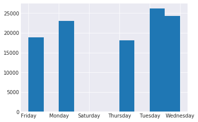

```python
#gives an idea about days of week in dataset
df['Day_Of_Week'].hist();
```

#### 4) Now dropping ScheduledDay column too as I will not be using it in futher steps.

```python
drop_column2=['ScheduledDay']
df.drop(columns=drop_column2,inplace=True)
```

```python
df.head()
```

|  | Gender | Age | Neighbourhood | Scholarship | Hipertension | Diabetes | Alcoholism | Handcap | SMS_received | No-show | Day_Of_Week |
| --- | --- | --- | --- | --- | --- | --- | --- | --- | --- | --- | --- |
| 0 | F | 62 | JARDIM DA PENHA | 0 | 1 | 0 | 0 | 0 | 0 | No | Friday |
| 1 | M | 56 | JARDIM DA PENHA | 0 | 0 | 0 | 0 | 0 | 0 | No | Friday |
| 2 | F | 62 | MATA DA PRAIA | 0 | 0 | 0 | 0 | 0 | 0 | No | Friday |
| 3 | F | 8 | PONTAL DE CAMBURI | 0 | 0 | 0 | 0 | 0 | 0 | No | Friday |
| 4 | F | 56 | JARDIM DA PENHA | 0 | 1 | 1 | 0 | 0 | 0 | No | Friday |

```python
df.shape
```

```
(110527, 11)
```

## Exploratory Data Analysis

### Research Question 1 - Is there any corelation between patient with existing problem like diabetes, alcoholism, etc.

```python
#segregating data on the basis of show or no-show
df_no_show=df[df['No-show']=='Yes']
df_show=df[df['No-show']=='No']
```

```python
# vis_hist function is used to visualize histogram
def vis_hist(_title,_xlabel,_ylabel,df_no_show_,df_show_):
    params = np.array([df_show_,df_no_show_])
    labels = ['Show','No-Show']
    plt.hist(params, label=labels)
    plt.title(_title)
    plt.xlabel(_xlabel)
    plt.ylabel(_ylabel)
    plt.xticks(np.arange(2),('No','Yes'))
    plt.legend()
    plt.show()
```

### Visual Representation between various ailments and show/no-show

#### 1) Diabetes

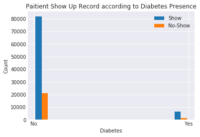

```python
title = 'Paitient Show Up Record according to Diabetes Presence'
ylabel='Count'
xlabel='Diabetes'
diabetes_show= df_show['Diabetes']
diabetes_no_show= df_no_show['Diabetes']
vis_hist(title,xlabel,ylabel,diabetes_no_show,diabetes_show)
```

#### 2) Alcoholism

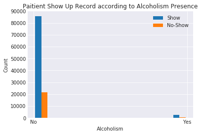

```python
title = 'Paitient Show Up Record according to Alcoholism Presence'
ylabel = 'Count'
xlabel = 'Alcoholism'
alcoholism_show = df_show['Alcoholism']
alcoholism_no_show = df_no_show['Alcoholism']
vis_hist(title, xlabel, ylabel, alcoholism_no_show, alcoholism_show)
```

#### 3) Hipertension

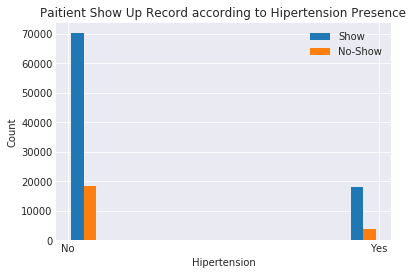

```python
title = 'Paitient Show Up Record according to Hipertension Presence'
ylabel='Count'
xlabel='Hipertension'
hipertension_show= df_show['Hipertension']
hipertension_no_show= df_no_show['Hipertension']
vis_hist(title,xlabel,ylabel,hipertension_no_show,hipertension_show)
```

#### 4) Handcap

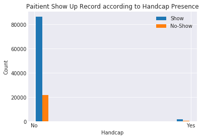

```python
title = 'Paitient Show Up Record according to Handcap Presence'
ylabel='Count'
xlabel='Handcap'
handcap_show= df_show['Handcap']
handcap_no_show= df_no_show['Handcap']
vis_hist(title,xlabel,ylabel,handcap_no_show,handcap_show)
```

##### After analysing the above histograms regarding various ailments I can see that there are very less number of paitents having diabetes, alcoholism and handcap. While hypertension paitents are more as compared to other ailments.

### Research Question 2 - Which Neighbourhood has most and least no-shows

```python
# function to visualize pie chart
def pie_vis (title, labels, input_data):
    plt.pie(input_data, labels=labels, autopct = '%1.1f%%', explode = (0.05,0.1),shadow=True)
    plt.title(title)
    plt.show()
```

```python
df['Neighbourhood'].nunique()
```

```
81
```

```python
#list of all neighbourhood regions
df['Neighbourhood'].unique()
```

```
array(['JARDIM DA PENHA', 'MATA DA PRAIA', 'PONTAL DE CAMBURI',
       'REPÚBLICA', 'GOIABEIRAS', 'ANDORINHAS', 'CONQUISTA',
       'NOVA PALESTINA', 'DA PENHA', 'TABUAZEIRO', 'BENTO FERREIRA',
       'SÃO PEDRO', 'SANTA MARTHA', 'SÃO CRISTÓVÃO', 'MARUÍPE',
       'GRANDE VITÓRIA', 'SÃO BENEDITO', 'ILHA DAS CAIEIRAS',
       'SANTO ANDRÉ', 'SOLON BORGES', 'BONFIM', 'JARDIM CAMBURI',
       'MARIA ORTIZ', 'JABOUR', 'ANTÔNIO HONÓRIO', 'RESISTÊNCIA',
       'ILHA DE SANTA MARIA', 'JUCUTUQUARA', 'MONTE BELO',
       'MÁRIO CYPRESTE', 'SANTO ANTÔNIO', 'BELA VISTA', 'PRAIA DO SUÁ',
       'SANTA HELENA', 'ITARARÉ', 'INHANGUETÁ', 'UNIVERSITÁRIO',
       'SÃO JOSÉ', 'REDENÇÃO', 'SANTA CLARA', 'CENTRO', 'PARQUE MOSCOSO',
       'DO MOSCOSO', 'SANTOS DUMONT', 'CARATOÍRA', 'ARIOVALDO FAVALESSA',
       'ILHA DO FRADE', 'GURIGICA', 'JOANA D´ARC', 'CONSOLAÇÃO',
       'PRAIA DO CANTO', 'BOA VISTA', 'MORADA DE CAMBURI', 'SANTA LUÍZA',
       'SANTA LÚCIA', 'BARRO VERMELHO', 'ESTRELINHA', 'FORTE SÃO JOÃO',
       'FONTE GRANDE', 'ENSEADA DO SUÁ', 'SANTOS REIS', 'PIEDADE',
       'JESUS DE NAZARETH', 'SANTA TEREZA', 'CRUZAMENTO',
       'ILHA DO PRÍNCIPE', 'ROMÃO', 'COMDUSA', 'SANTA CECÍLIA',
       'VILA RUBIM', 'DE LOURDES', 'DO QUADRO', 'DO CABRAL', 'HORTO',
       'SEGURANÇA DO LAR', 'ILHA DO BOI', 'FRADINHOS', 'NAZARETH',
       'AEROPORTO', 'ILHAS OCEÂNICAS DE TRINDADE', 'PARQUE INDUSTRIAL'], dtype=object)
```

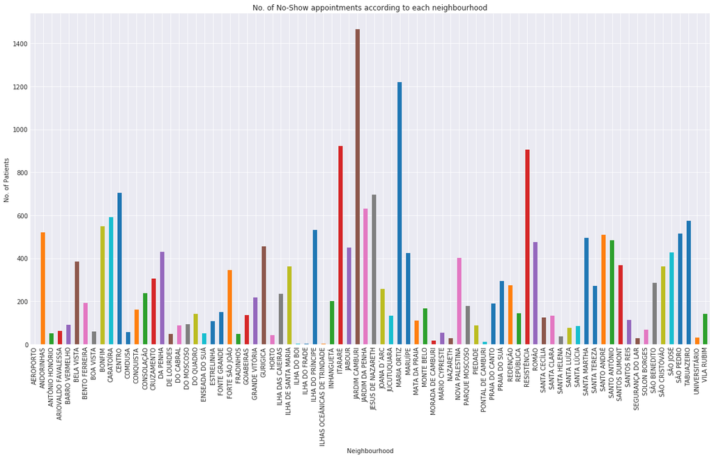

```python
# histogram of no. of no-show appointments according to each neighbourhood
df_no_show_ngh_count = df_no_show.groupby('Neighbourhood')['No-show'].count()
df_no_show_ngh_count.plot(kind='bar',title = 'No. of No-Show appointments according to each neighbourhood',figsize=(20,10))
plt.xlabel('Neighbourhood')
plt.ylabel('No. of Patients')
plt.show()
```

```python
# top 5 neighburhood with highest no-show
df_no_show_ngh_count.sort_values(ascending=False).head()
```

```
Neighbourhood
JARDIM CAMBURI    1465
MARIA ORTIZ       1219
ITARARÉ            923
RESISTÊNCIA        906
CENTRO             703
Name: No-show, dtype: int64
```

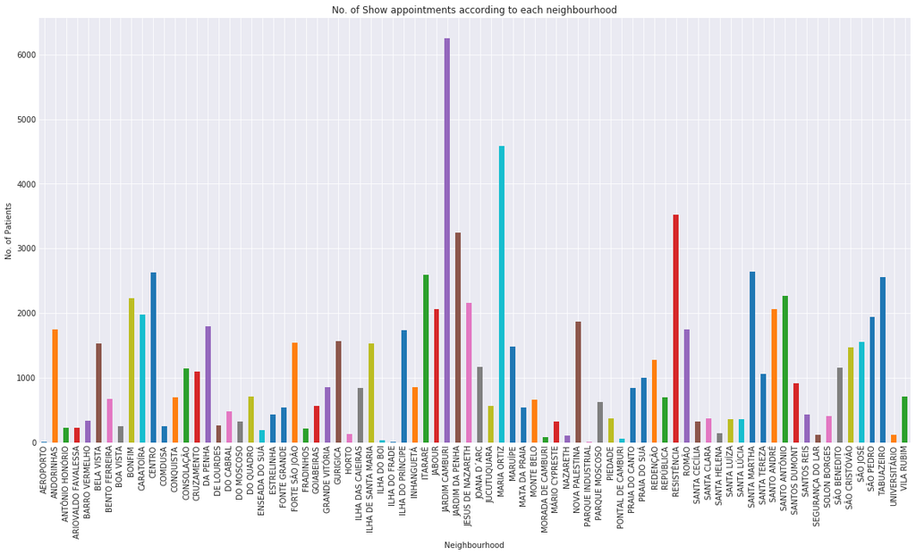

```python
# histogram of no. of no-show appointments according to each neighbourhood
df_show_ngh_count = df_show.groupby('Neighbourhood')['No-show'].count()
df_show_ngh_count.plot(kind='bar',title = 'No. of Show appointments according to each neighbourhood',figsize=(20,10))
plt.xlabel('Neighbourhood')
plt.ylabel('No. of Patients')
plt.show()
```

```python
# top 5 neighburhood with highest show
df_show_ngh_count.sort_values(ascending=False).head()
```

```
Neighbourhood
JARDIM CAMBURI     6252
MARIA ORTIZ        4586
RESISTÊNCIA        3525
JARDIM DA PENHA    3246
SANTA MARTHA       2635
Name: No-show, dtype: int64
```

### Percentage of show and no show in top 5 no-show neighbourhoods

##### 1) JARDIM CAMBURI

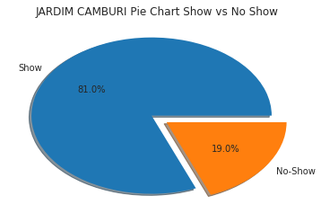

```python
title='JARDIM CAMBURI Pie Chart Show vs No Show'
labels=['Show','No-Show']
input_data=[df_show_ngh_count['JARDIM CAMBURI'],df_no_show_ngh_count['JARDIM CAMBURI']]
pie_vis (title, labels, input_data)
```

#### 2) MARIA ORTIZ

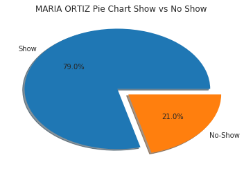

```python
title='MARIA ORTIZ Pie Chart Show vs No Show'
labels=['Show','No-Show']
input_data=[df_show_ngh_count['MARIA ORTIZ'],df_no_show_ngh_count['MARIA ORTIZ']]
pie_vis (title, labels, input_data)
```

#### 3) ITARARÉ

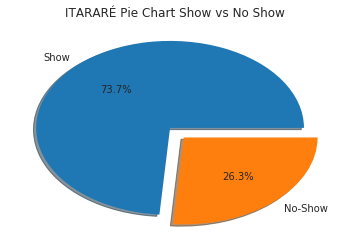

```python
title='ITARARÉ Pie Chart Show vs No Show'
labels=['Show','No-Show']
input_data=[df_show_ngh_count['ITARARÉ'],df_no_show_ngh_count['ITARARÉ']]
pie_vis (title, labels, input_data)
```

#### 4) RESISTÊNCIA

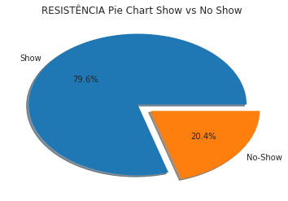

```python
title='RESISTÊNCIA Pie Chart Show vs No Show'
labels=['Show','No-Show']
input_data=[df_show_ngh_count['RESISTÊNCIA'],df_no_show_ngh_count['RESISTÊNCIA']]
pie_vis (title, labels, input_data)
```

#### 5) CENTRO

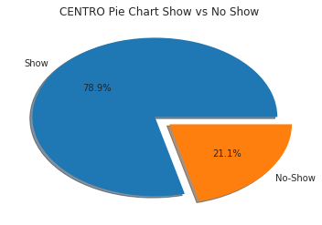

```python
title='CENTRO Pie Chart Show vs No Show'
labels=['Show','No-Show']
input_data=[df_show_ngh_count['CENTRO'],df_no_show_ngh_count['CENTRO']]
pie_vis (title, labels, input_data)
```

##### We can clearly see that almost all the top 5 neighbourhoods with highest no-shows have no-show percentage close to 20% except one ie. ITARARÉ which has no-show percentage close to 26% hence we should look into the reason why this neighbourhood has highest percentage among all. A possible explanation can be distance of this neighbourhood from the hospital.

### Research Question 3 - Is there some co-relation between day of week and no-show or showing for appointments

```python
# function to find count number of days of week present in a dataframe. Sunday was not considered as above I have already
# cheked and there are only 6 unique value in the dataframe and sunday is not one of them.
def week_count(_df_weeks):
    _mon=_df_weeks.query('Day_Of_Week == "Monday"')['Day_Of_Week'].count()
    _tue=_df_weeks.query('Day_Of_Week == "Tuesday"')['Day_Of_Week'].count()
    _wed=_df_weeks.query('Day_Of_Week == "Wednesday"')['Day_Of_Week'].count()
    _thurs=_df_weeks.query('Day_Of_Week == "Thursday"')['Day_Of_Week'].count()
    _fri=_df_weeks.query('Day_Of_Week == "Friday"')['Day_Of_Week'].count()
    _sat=_df_weeks.query('Day_Of_Week == "Saturday"')['Day_Of_Week'].count()

    day_week_count=[_mon,_tue,_wed,_thurs,_fri,_sat]
    return day_week_count
```

```python
labels=['Monday','Tuesday','Wednesday','Thursday','Friday','Saturday']
positions = [1,2,3,4,5,6]
```

#### No-Show Days of Week Count

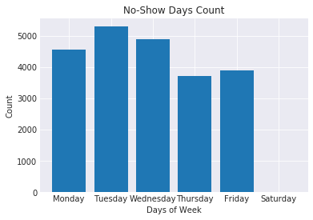

```python
#Visualization of no-show in each days of week
noshow_day_count=week_count(df_no_show)
plt.bar(positions,noshow_day_count,tick_label=labels)
plt.title('No-Show Days Count')
plt.xlabel('Days of Week')
plt.ylabel('Count')
plt.show()
```

#### Show Days of Week Count

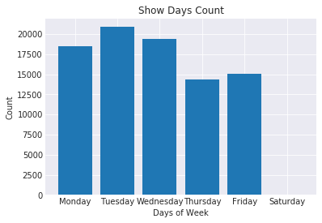

```python
#Visualization of show-up in each days of week
show_day_count=week_count(df_show)
plt.bar(positions,show_day_count,tick_label=labels)
plt.title('Show Days Count')
plt.xlabel('Days of Week')
plt.ylabel('Count')
plt.show()
```

##### Looking at the above two charts I can conclude that there is usually more patients on Tuesday hence its count is the highest in both no-show and show graphs. While Saturday has least amount of patitents appointments. It can also be seen from initial analysis that no appointments are being taken on Sundays.

### Research Question 4 - Does sending of SMS have any effect number of no-shows ?

```python
sms_show = df_show['SMS_received']
sms_no_show = df_no_show['SMS_received']
```

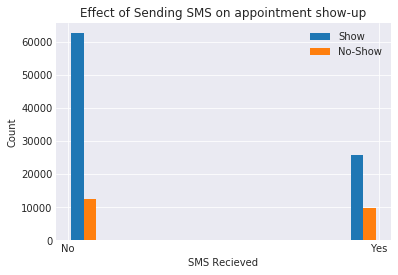

```python
title = 'Effect of Sending SMS on appointment show-up'
xlabel = 'SMS Recieved'
ylabel='Count'
vis_hist(title,xlabel,ylabel,sms_no_show,sms_show)
```

##### We can clearly see in histogram above that the SMS does not seems to be effective in showing up for appointment

## Conclusions

### Result of each Question -

> **Research Question 1 :** After looking at the histograms of diabetes, hypertension, alcoholism and handcap it is visible that paitents having these ailments are very less in numbers as compared to paitents not having these ailment so it will not be right to conclude anything from them

> **Research Question 3 :** The histogram of both show up and no show up looks identical hence no correlation can be found between days of week and show/no-show up

##### After all these analysis I can conclude that none of the factors above, stand alone can not determine possiblity of a paitents' show or no-show we would require more factors, like distance paitents have to travel to reach the hospital, availability of doctors each day, etc. and a group of factors have to be used to determine probability of show-up.

### Limitations -

> **1** We do not know answers of question like Why paitents' are not showing up even after a SMS reminder

> **2** Few neighbourhood have very high no-show up as compared to other we will require few more details to know why is it so.

> **3** Information of doctor's availabilty and details will also be vital to figure out reason for no-show

## Submitting Project

```python
from subprocess import call
call(['python', '-m', 'nbconvert', 'Investigate_a_Dataset.ipynb'])
```

```
0
```